# E11.5 cortex

`r`r library(COTAN)

```
There were 13 warnings (use warnings() to see them)
```

`r`r library(data.table) library(Matrix) library(ggrepel) #library(latex2exp)

`r`r data_dir = /

`r`r data = as.data.frame(fread(paste(data_dir,2861510_E115_Only_Cortical_Cells_DGE.txt.gz, sep = /))) data = as.data.frame(data) rownames(data) = data$V1 data = data[,2:ncol(data)] data[1:10,1:10]

|  | ATGTAGTACCGA | TCAACTTCATAT | ATGAAAGACCAT | CCGTACCGCGTA | ATCACCCGTGTT | ATCTCCGCACGT | CCCTTCTCCTAC | AATCAGTTGCTT | AGTAAAGGACTT | CTGCGCTTACCT |
| --- | --- | --- | --- | --- | --- | --- | --- | --- | --- | --- |
| 0610005C13Rik | 0 | 0 | 0 | 0 | 0 | 0 | 0 | 0 | 0 | 0 |
| 0610007N19Rik | 0 | 0 | 0 | 0 | 3 | 0 | 1 | 2 | 0 | 0 |
| 0610007P14Rik | 0 | 0 | 2 | 2 | 1 | 2 | 0 | 3 | 1 | 0 |
| 0610009B22Rik | 2 | 0 | 0 | 2 | 0 | 1 | 0 | 1 | 0 | 1 |
| 0610009D07Rik | 4 | 6 | 5 | 5 | 3 | 1 | 4 | 2 | 5 | 7 |
| 0610009E02Rik | 0 | 0 | 0 | 0 | 0 | 0 | 1 | 0 | 0 | 0 |
| 0610009L18Rik | 0 | 0 | 1 | 1 | 0 | 0 | 1 | 0 | 0 | 0 |
| 0610009O20Rik | 0 | 2 | 0 | 0 | 0 | 0 | 1 | 0 | 1 | 0 |
| 0610010F05Rik | 0 | 0 | 2 | 0 | 1 | 5 | 1 | 1 | 0 | 0 |
| 0610010K14Rik | 0 | 0 | 0 | 0 | 0 | 0 | 0 | 0 | 0 | 0 |

Define a directory where the ouput will be stored.

`r`r out_dir = /

# 1 Analitical pipeline

Inizialise the COTAN object with the row count table and the metadata for the experiment.

```
[1] \Initializing S4 object\
```

Now we can start the cleaning. Analysis requires and starts from a matrix of raw UMI counts after removing possible cell doublets or multiplets and low quality or dying cells (with too high mtRNA percentage, easily done with Seurat or other tools).

If we do not want to consider the mithocondrial genes we can remove them before starting the analysis.

`r`r genes_to_rem = rownames(obj@raw[grep(‘^mt’, rownames(obj@raw)),]) #genes to remove : mithocondrial obj@raw = obj@raw[!rownames(obj@raw) %in% genes_to_rem,] cells_to_rem = colnames(obj@raw[which(colSums(obj@raw) == 0)]) obj@raw = obj@raw[,!colnames(obj@raw) %in% cells_to_rem]

We want also to define a prefix to identify the sample.

`r`r t = 11_cortex_clean

print(paste(,t,sep = \))

```
[1] \Condition E11_cortex_clean\
```

`r`r #————————————– n_cells = length(colnames(obj@raw)) print(paste(cells, n_cells, sep = ))

```
[1] \n cells 1418\
```

`r`r n_it = 1

#obj@raw = obj@raw[rownames(cells), colnames(cells)]

# 2 Data cleaning

First we create the directory to store all information regardin the data cleaning.

`r`r if(!file.exists(out_dir)){ dir.create(file.path(out_dir)) }

if(!file.exists(paste(out_dir,, sep = \))){  
dir.create(file.path(out_dir, )) }

`r`r ttm = clean(obj)

```
[1] \Start estimation mu with linear method\
[1] 12549  1418
```

`r`r obj = ttm$object

ttm$pca.cell.2

|  | rowname | CAGAGCTTTACG | GCCCCTCACGAT | CGGCAACTATCA | GGCGGAGGCGTA | TGTTAGCGCGGA | ATGGATCTCATT |
| --- | --- | --- | --- | --- | --- | --- | --- |
| 5167 | Hbb-y | 174.578095 | 340.178647 | 224.552985 | 329.057856 | 131.348618 | 509.114655 |
| 5163 | Hba-x | 112.695946 | 117.536808 | 129.919941 | 171.739359 | 76.043937 | 295.226249 |
| 5162 | Hba-a1 | 44.776514 | 149.181333 | 65.761945 | 60.305424 | 93.326650 | 96.400408 |
| 5164 | Hbb-bh1 | 57.354187 | 24.863556 | 48.118497 | 73.415299 | 3.456543 | 156.650663 |
| 5354 | Hnrnpa2b1 | 8.049710 | 19.212747 | 14.435549 | 11.798887 | 6.913085 | 0.000000 |
| 5417 | Hsp90ab1 | 13.583886 | 14.692101 | 9.623699 | 7.865925 | 3.456543 | 9.037538 |
| 5166 | Hbb-bt | 1.509321 | 13.561939 | 6.415800 | 19.664812 | 13.826170 | 3.012513 |
| 4081 | Fth1 | 9.559031 | 13.561939 | 6.415800 | 10.487900 | 3.456543 | 12.050051 |
| 6294 | Malat1 | 3.521748 | 10.171455 | 12.831599 | 3.932962 | 13.826170 | 6.025025 |
| 682 | Actb | 5.031069 | 2.260323 | 8.019749 | 11.798887 | 10.369628 | 12.050051 |

[output cut: 5 more lines]

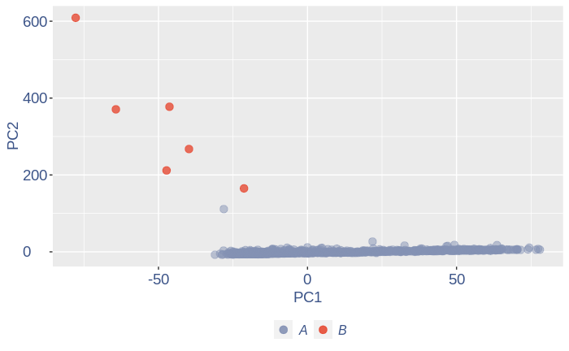

Run this when B cells need to be removed.

`r`r pdf(paste(out_dir,/,t,_,n_it,_plots_before_cells_exlusion.pdf, sep = \)) ttm$pca.cell.2 ggplot(ttm$D, aes(x=n,y=means)) + geom_point() + geom_text_repel(data=subset(ttm$D, n > (max(ttm$D$n)- 15) ), aes(n,means,label=rownames(ttm$D[ttm$D$n > (max(ttm$D$n)- 15),])), nudge_y = 0.05, nudge_x = 0.05, direction = , angle = 90, vjust = 0, segment.size = 0.2)+ ggtitle(cell group genes mean expression)+my_theme + theme(plot.title = element_text(color = #3C5488FF, size = 20, face = ,vjust = - 5,hjust = 0.02 )) dev.off()

`r`r if (length(ttm$cl1) < length(ttm$cl2)) { to_rem = ttm$cl1 }else{ to_rem = ttm$cl2 } n_it = n_it+1 obj@raw = obj@raw[,!colnames(obj@raw) %in% to_rem] #obj@raw = obj@raw[rownames(obj@raw) %in% rownames(cells),colnames(obj@raw) %in% colnames(cells)] gc()

```
            used  (Mb) gc trigger    (Mb)   max used    (Mb)
Ncells   4220238 225.4    7154375   382.1    7154375   382.1
Vcells 121276979 925.3 1583441045 12080.7 3092654997 23595.1
```

`r`r ttm = clean(obj)

```
[1] \Start estimation mu with linear method\
[1] 12543  1412
```

`r`r #ttm = clean.sqrt(obj, cells) obj = ttm$object

ttm$pca.cell.2

|  | rowname | GCATATTACGCC | TGAGAGCGAAGG |
| --- | --- | --- | --- |
| 6291 | Malat1 | 278.591783 | 350.707493 |
| 7296 | Nnat | 49.370696 | 11.888390 |
| 6513 | Meg3 | 3.526478 | 53.497753 |
| 1353 | Atrx | 10.579435 | 23.776779 |
| 11430 | Tuba1a | 28.211826 | 5.944195 |
| 11104 | Tmsb10 | 28.211826 | 0.000000 |
| 839 | Akap9 | 0.000000 | 23.776779 |
| 681 | Actb | 17.632391 | 5.944195 |
| 6230 | Luc7l3 | 3.526478 | 17.832584 |
| 7618 | Pa2g4 | 3.526478 | 17.832584 |

[output cut: 5 more lines]

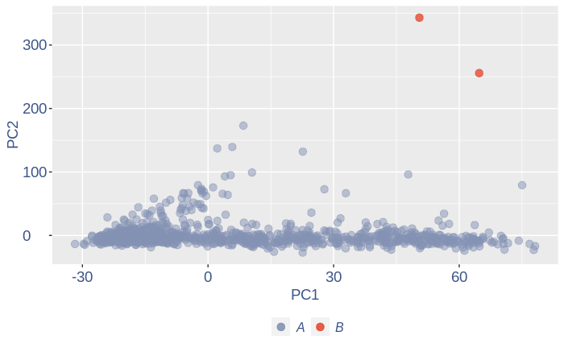

[output not shown]

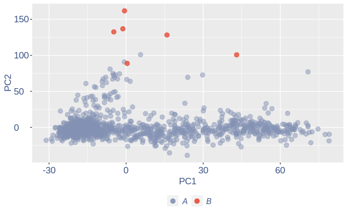

|  | rowname | GTAGCCAATCAA | GCACACGCCTCA | TCGATGCTCCGG | CGGCTGTTCCGC | CCCATCCCGGGC | TATATAAGTATC |
| --- | --- | --- | --- | --- | --- | --- | --- |
| 6289 | Malat1 | 137.826998 | 139.765012 | 182.524171 | 96.726725 | 103.235520 | 136.543974 |
| 7293 | Nnat | 0.000000 | 0.000000 | 0.000000 | 73.967496 | 16.517683 | 5.461759 |
| 11981 | Ybx1 | 8.892064 | 7.764723 | 4.148277 | 11.379615 | 20.647104 | 16.385277 |
| 11427 | Tuba1a | 4.446032 | 0.000000 | 0.000000 | 34.138844 | 4.129421 | 10.923518 |
| 9335 | Rps9 | 0.000000 | 11.647084 | 12.444830 | 5.689807 | 12.388262 | 10.923518 |
| 5646 | Islr2 | 0.000000 | 0.000000 | 4.148277 | 28.449037 | 8.258842 | 10.923518 |
| 11942 | Xist | 13.338097 | 15.529446 | 0.000000 | 11.379615 | 0.000000 | 10.923518 |
| 9692 | Sfrs18 | 8.892064 | 23.294169 | 4.148277 | 0.000000 | 4.129421 | 0.000000 |
| 11439 | Tubb5 | 0.000000 | 7.764723 | 16.593106 | 0.000000 | 4.129421 | 10.923518 |
| 6510 | Meg3 | 4.446032 | 0.000000 | 24.889660 | 0.000000 | 8.258842 | 0.000000 |

[output cut: 5 more lines]

Run this only in the last iteration, instead the previus code, when B cells group has not to be removed

`r`r pdf(paste(out_dir,/,t,_,n_it,_plots_before_cells_exlusion.pdf, sep = \)) ttm$pca.cell.2 ggplot(ttm$D, aes(x=n,y=means)) + geom_point() + geom_text_repel(data=subset(ttm$D, n > (max(ttm$D$n)- 15) ), aes(n,means,label=rownames(ttm$D[ttm$D$n > (max(ttm$D$n)- 15),])), nudge_y = 0.05, nudge_x = 0.05, direction = , angle = 90, vjust = 0, segment.size = 0.2)+ ggtitle(label = cell group genes mean expression, subtitle = - B group NOT removed -)+my_theme + theme(plot.title = element_text(color = #3C5488FF, size = 20, face = ,vjust = - 10,hjust = 0.02 ), plot.subtitle = element_text(color = ,vjust = - 15,hjust = 0.01 ))

dev.off()

To color the pca based on nu_j (so the cells’ efficiency)

`r`r nu_est = round(obj@nu, digits = 7)

plot.nu <-ggplot(ttm$pca_cells,aes(x=PC1,y=PC2, colour = log(nu_est)))

plot.nu = plot.nu + geom_point(size = 1,alpha= 0.8)+ scale_color_gradient2(low = #E64B35B2,mid = #4DBBD5B2, high = #3C5488B2 , midpoint = log(mean(nu_est)),name = (nu))+ ggtitle(PCA coloured by cells efficiency) + my_theme + theme(plot.title = element_text(color = #3C5488FF, size = 20), legend.title=element_text(color = #3C5488FF, size = 14,face = ), legend.text = element_text(color = #3C5488FF, size = 11), legend.key.width = unit(2, ), legend.position=)

pdf(paste(out_dir,/,t,_plots_PCA_efficiency_colored.pdf, sep = \)) plot.nu dev.off()

`r`r plot.nu

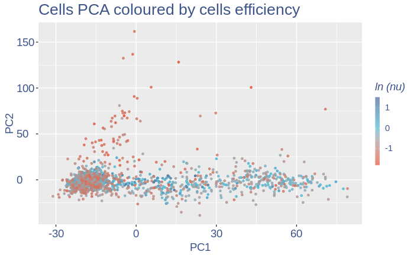

The next part is use to remove the cells with efficiency too low.

`r`r ggplot(nu_df, aes(x = n, y=nu)) + geom_point(colour = #8491B4B2, size=1)+ my_theme #+ ylim(0,1) + xlim(0,70)

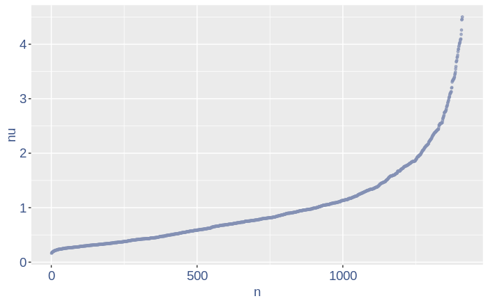

We can zoom on the smalest values and, if we detect a clear elbow, we can decide to remove the cells.

`r`r yset = 0.21#threshold to remove low UDE cells plot.ude <- ggplot(nu_df, aes(x = n, y=nu)) + geom_point(colour = #8491B4B2, size=1) + my_theme + ylim(0.,0.4) + xlim(0,200) + geom_hline(yintercept=yset, linetype=, color = ) + annotate(geom=, x=500, y=0.5, label=paste(remove cells with nu < ,yset,sep = ), color=, size=4.5)

pdf(paste(out_dir,/,t,_plots_efficiency.pdf, sep = \)) plot.ude dev.off()

`r`r plot.ude

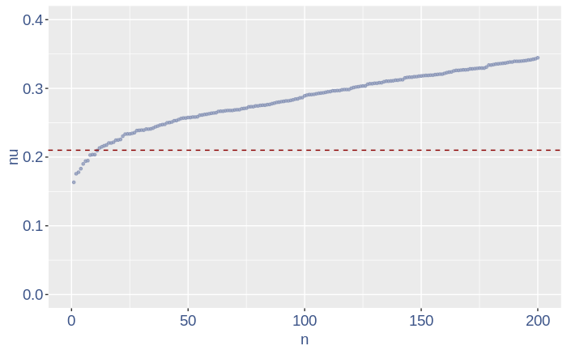

We also save the defined treshold in the metadata and re run the estimation

`r`r obj@meta[(nrow(obj@meta)+1),1:2] = c(low UDE cells:,yset)

to_rem = rownames(nu_df[which(nu_df$nu < yset),])

obj@raw = obj@raw[, !colnames(obj@raw) %in% to_rem]

Repeat the estimation after the cells are removed

`r`r ttm = clean(obj)

```
[1] \Start estimation mu with linear method\
[1] 12537  1399
```

`r`r obj = ttm$object ttm$pca.cell.2

|  | rowname | GTAGCCAATCAA | GCACACGCCTCA | TCGATGCTCCGG |
| --- | --- | --- | --- | --- |
| 6288 | Malat1 | 138.703643 | 140.653984 | 183.685111 |
| 9691 | Sfrs18 | 8.948622 | 23.442331 | 4.174662 |
| 6509 | Meg3 | 4.474311 | 0.000000 | 25.047970 |
| 11940 | Xist | 13.422933 | 15.628220 | 0.000000 |
| 9308 | Rps26 | 0.000000 | 19.535276 | 8.349323 |
| 6227 | Luc7l3 | 13.422933 | 7.814110 | 4.174662 |
| 1502 | Baz1b | 8.948622 | 7.814110 | 8.349323 |
| 10221 | Son | 8.948622 | 11.721165 | 4.174662 |
| 11438 | Tubb5 | 0.000000 | 7.814110 | 16.698646 |
| 9334 | Rps9 | 0.000000 | 11.721165 | 12.523985 |

[output cut: 5 more lines]

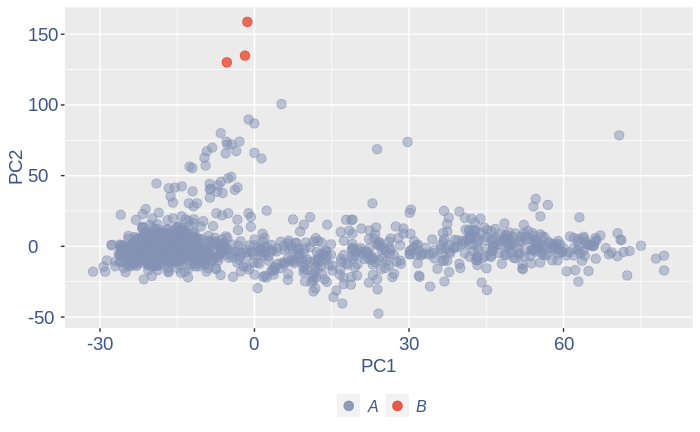

Just to check again, we plot the final efficiency colored PCA

`r`r nu_est = round(obj@nu, digits = 7) plot.nu <-ggplot(ttm$pca_cells,aes(x=PC1,y=PC2, colour = log(nu_est))) plot.nu = plot.nu + geom_point(size = 2,alpha= 0.8)+ scale_color_gradient2(low = #E64B35B2,mid = #4DBBD5B2, high = #3C5488B2 , midpoint = log(mean(nu_est)),name = (nu))+ ggtitle(PCA coloured by cells efficiency: last) + my_theme + theme(plot.title = element_text(color = #3C5488FF, size = 20), legend.title=element_text(color = #3C5488FF, size = 14,face = ), legend.text = element_text(color = #3C5488FF, size = 11), legend.key.width = unit(2, ), legend.position=)

pdf(paste(out_dir,/,t,_plots_PCA_efficiency_colored_FINAL.pdf, sep = \)) plot.nu dev.off()

`r`r plot.nu

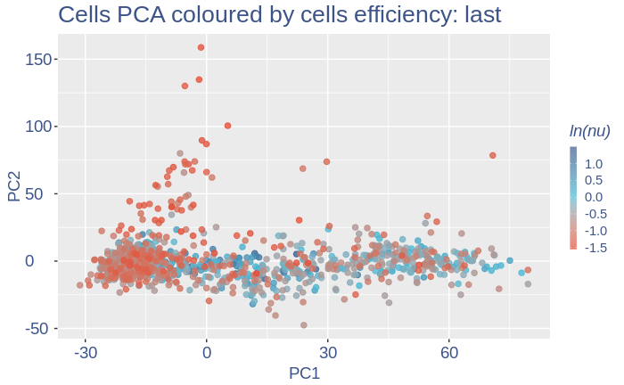

COTAN analysis: in this part all the contingency tables are computed and used to get the statistics (S) To storage efficincy of all the observed tables only the yes_yes is stored. Note that if will be necessary re-coputing the yes-yes table, the yes-yes table should be cancelled before running cotan_analysis.

```r
# obj@yes_yes = c()
obj = cotan_analysis(obj)
```

COEX evaluation and storing

```r
saveRDS(obj,file = paste(out_dir,t,".cotan.RDS", sep = ""))

obj = get.coex(obj)

# saving the structure
saveRDS(obj,file = paste(out_dir,t,".cotan.RDS", sep = ""))
```

Automatic data elaboration (without cleaning)

`r`r obj2 = automatic.COTAN.object.creation(df = data,GEO=2861510 ,sc.method=-seq,cond = 11_cortex, out_dir = /)

```
[1] \Initializing S4 object\
[1] \Condition E11_cortex\
[1] \n cells 1418\
[1] \Start estimation mu with linear method\
[1] 12549  1418
[1] \Cotan analysis function started\
[1] \cotan analysis\
[1] \mu estimator creation\
[1] \save effective constitutive genes\
[1] \start a minimization\
[1] \Next gene: Capn2 number 1810\
[1] \Next gene: Fam83h number 3820\
[1] \Next gene: Kidins220 number 5830\
[1] \Next gene: Pds5a number 7840\
[1] \Next gene: Slc18b1 number 9850\
```

[output cut: 17 more lines]

|  | rowname | CAGAGCTTTACG | GCCCCTCACGAT | CGGCAACTATCA | GGCGGAGGCGTA | TGTTAGCGCGGA | ATGGATCTCATT |
| --- | --- | --- | --- | --- | --- | --- | --- |
| 5167 | Hbb-y | 174.578095 | 340.178647 | 224.552985 | 329.057856 | 131.348618 | 509.114655 |
| 5163 | Hba-x | 112.695946 | 117.536808 | 129.919941 | 171.739359 | 76.043937 | 295.226249 |
| 5162 | Hba-a1 | 44.776514 | 149.181333 | 65.761945 | 60.305424 | 93.326650 | 96.400408 |
| 5164 | Hbb-bh1 | 57.354187 | 24.863556 | 48.118497 | 73.415299 | 3.456543 | 156.650663 |
| 5354 | Hnrnpa2b1 | 8.049710 | 19.212747 | 14.435549 | 11.798887 | 6.913085 | 0.000000 |
| 5417 | Hsp90ab1 | 13.583886 | 14.692101 | 9.623699 | 7.865925 | 3.456543 | 9.037538 |
| 5166 | Hbb-bt | 1.509321 | 13.561939 | 6.415800 | 19.664812 | 13.826170 | 3.012513 |
| 4081 | Fth1 | 9.559031 | 13.561939 | 6.415800 | 10.487900 | 3.456543 | 12.050051 |
| 6294 | Malat1 | 3.521748 | 10.171455 | 12.831599 | 3.932962 | 13.826170 | 6.025025 |
| 682 | Actb | 5.031069 | 2.260323 | 8.019749 | 11.798887 | 10.369628 | 12.050051 |

[output cut: 5 more lines]

# 3 Analysis of the elaborated data

In this case the test possible macroscopic differences between cleaned and not cleaned data.

The initial cell number was:

```r
obj = readRDS(paste(out_dir,t,".cotan.RDS", sep = ""))
obj@meta
```

```
Object of class "data.frame"
```

|  | V1 | V2 |
| --- | --- | --- |
| 1 | GEO: | GSM2861510 |
| 2 | scRNAseq method: | DropSeq |
| 3 | starting n. of cells: | 1418 |
| 4 | Condition sample: | mouse cortex E11.5 |
| 5 | Threshold low UDE cells: | 0.21 |

While the final number of cells was:

```r
ncol(obj@raw)
```

```
[1] 1399
```

So were removed:

```r
as.numeric(obj@meta[3,2]) - ncol(obj@raw)
```

```
[1] 19
```

cells

## 3.1 GDI with cleaning

```r
quant.p = get.GDI(obj)
```

```
[1] "function to generate GDI dataframe"
[1] "Using S"
[1] "function to generate S "
```

In the third column of this dataframe is reported the percentage of cells expressing the gene.